# TMA4268 Statistical Learning

Chapter 10: Unsupervised Learning - NYT Stories

Thiago G. Martins, Department of Mathematical Sciences, NTNU

Spring 2020

# PCA on New York Times stories

This example (code and data) are based on the [lecture](http://www.stat.cmu.edu/~cshalizi/490/10/) of Brian Junker and Cosma Shalizi about Principal components and factor analysis.

You can download the `pca-examples.Rdata` on our course website.

## Data Exploration

New stories randomly selected from the [New York Times Annotated Corpus](https://catalog.ldc.upenn.edu/ldc2008t19). There are 57 stories about art and 45 about music on the dataset available.

```r
# Modify the location based on your filesystem
load("../10_unsupervised_learning/datasets/pca-examples.Rdata")

# We will work with nyt.frame
nyt_data = nyt.frame
```

The `nyt_data` is a dataset containing 102 observations (102 new stories) and columns containing class labels of the stories (art and music) and the count of each word in a given story (weight by the inverse document frequency and normalized by vector length).

```r
str(nyt_data)
```

```
## 'data.frame':    102 obs. of  4432 variables:
##  $ class.labels    : Factor w/ 2 levels "art","music": 1 1 1 1 1 1 1 1 1 1 ...
##  $ X.              : num  0.00871 0.00585 0.01604 0.02641 0.00729 ...
##  $ X.d             : num  0 0 0 0 0 ...
##  $ X.nd            : num  0 0 0 0 0 0 0 0 0 0 ...
##  $ X.s             : num  0 0 0.0114 0 0.011 ...
##  $ X.th            : num  0.00925 0 0 0 0 ...
##  $ X.this          : num  0 0 0 0 0 ...
##  $ a               : num  0.00756 0.00142 0.01006 0.00868 0.00839 ...
##  $ abandoned       : num  0 0 0 0 0 0 0 0 0 0 ...
##  $ abc             : num  0 0 0 0 0 0 0 0 0 0 ...
##  $ ability         : num  0 0 0 0 0 0 0 0 0 0 ...
##  $ able            : num  0 0.0399 0 0 0 ...
##  $ about           : num  0.0533 0 0 0.0125 0 ...
##  $ above           : num  0 0 0.0536 0 0 ...
```

[output cut: 86 more lines]

```r
summary(nyt_data$class.labels)
```

```
##   art music
##    57    45
```

Let’s check some word samples:

```r
colnames(nyt_data)[sample(ncol(nyt_data),30)]
```

```
##  [1] "penchant"  "brought"   "structure" "willing"   "yielding"
##  [6] "bare"      "school"    "halls"     "challenge" "step"
## [11] "largest"   "lovers"    "intense"   "borders"   "mall"
## [16] "classic"   "conducted" "mirrors"   "hole"      "location"
## [21] "desperate" "published" "head"      "paints"    "another"
## [26] "starts"    "familiar"  "window"    "thats"     "broker"
```

Let’s check some values in the dataset. We have many zeroes, as most words do not appear in most stories.

```r
signif(nyt_data[sample(nrow(nyt_data),5),sample(ncol(nyt_data),10)],3)
```

```
##    jacket patch tapes   want   ford failed condemn intentional confined
## 24      0     0     0 0.0000 0.0000 0.0000       0           0        0
## 2       0     0     0 0.0275 0.0704 0.0000       0           0        0
## 85      0     0     0 0.0482 0.0000 0.0000       0           0        0
## 59      0     0     0 0.0000 0.0000 0.0000       0           0        0
## 76      0     0     0 0.0000 0.0000 0.0215       0           0        0
##    destroyed
## 24         0
## 2          0
## 85         0
## 59         0
## 76         0
```

## PCA

We will now perform PCA. We exclude the first column since it is related to the response of the data. We did not set `scale=TRUE` because the data has already been normalized.

```r
nyt_pca = prcomp(nyt_data[,-1])
```

### Loadings

Note that we can have at most 102 PCs in this case.

```r
nyt_loading = nyt_pca$rotation
dim(nyt_loading)
```

```
## [1] 4431  102
```

```r
signif(nyt_loading[sample(nrow(nyt_loading),5),sample(ncol(nyt_loading),10)],3)
```

```
##                 PC57     PC86     PC70      PC30     PC90     PC53
## display     -0.01220  0.00697 -0.00888 -0.011200  0.01630 -0.00246
## feminist     0.00365  0.01830  0.00131 -0.021800 -0.01170 -0.03150
## posturing   -0.00165  0.02020  0.00473  0.000924 -0.00708 -0.01140
## emotionally  0.00194  0.02900  0.00470  0.002250 -0.00552 -0.03400
## finally      0.00973 -0.00408  0.00160  0.008220  0.00737 -0.01060
##                  PC27     PC32      PC88     PC59
## display     -0.001150  0.00257 -0.004390 -0.00447
## feminist     0.016800  0.00121 -0.005450 -0.00646
## posturing    0.000349  0.00834  0.000553 -0.00466
## emotionally -0.004020 -0.00187 -0.007260 -0.00595
## finally     -0.009170  0.00992  0.007140  0.01370
```

Show the 30 words with the biggest positive loading on PC1:

```r
signif(sort(nyt_loading[,1],decreasing=TRUE)[1:30],2)
```

```
##       music        trio     theater   orchestra   composers       opera
##       0.110       0.084       0.083       0.067       0.059       0.058
##    theaters           m    festival        east     program           y
##       0.055       0.054       0.051       0.049       0.048       0.048
##      jersey     players   committee      sunday        june     concert
##       0.047       0.047       0.046       0.045       0.045       0.045
##    symphony       organ     matinee   misstated instruments           p
##       0.044       0.044       0.043       0.042       0.041       0.041
##         X.d       april      samuel        jazz     pianist     society
##       0.041       0.040       0.040       0.039       0.038       0.038
```

Show the 30 words with the biggest negative loading on PC1:

```r
signif(sort(nyt_loading[,1],decreasing=FALSE)[1:30],2)
```

```
##       she       her        ms         i      said    mother    cooper
##    -0.260    -0.240    -0.200    -0.150    -0.130    -0.110    -0.100
##        my  painting   process paintings        im        he       mrs
##    -0.094    -0.088    -0.071    -0.070    -0.068    -0.065    -0.065
##        me  gagosian       was   picasso     image sculpture      baby
##    -0.063    -0.062    -0.058    -0.057    -0.056    -0.056    -0.055
##   artists      work    photos       you    nature    studio       out
##    -0.055    -0.054    -0.051    -0.051    -0.050    -0.050    -0.050
##      says      like
##    -0.050    -0.049
```

Show the 30 words with the biggest positive loading on PC2:

```r
signif(sort(nyt_loading[,2],decreasing=TRUE)[1:30],2)
```

```
##         art      museum      images     artists   donations     museums
##       0.150       0.120       0.095       0.092       0.075       0.073
##    painting         tax   paintings   sculpture     gallery  sculptures
##       0.073       0.070       0.065       0.060       0.055       0.051
##     painted       white    patterns      artist      nature     service
##       0.050       0.050       0.047       0.047       0.046       0.046
##  decorative        feet     digital      statue       color    computer
##       0.043       0.043       0.043       0.042       0.042       0.041
##       paris         war collections     diamond       stone     dealers
##       0.041       0.041       0.041       0.041       0.041       0.040
```

```r
signif(sort(nyt_loading[,2],decreasing=FALSE)[1:30],2)
```

```
##          her          she      theater        opera           ms
##       -0.220       -0.220       -0.160       -0.130       -0.130
##            i         hour   production         sang     festival
##       -0.083       -0.081       -0.075       -0.075       -0.074
##        music      musical        songs        vocal    orchestra
##       -0.070       -0.070       -0.068       -0.067       -0.067
##           la      singing      matinee  performance         band
##       -0.065       -0.065       -0.061       -0.061       -0.060
##       awards    composers         says           my           im
##       -0.058       -0.058       -0.058       -0.056       -0.056
##         play     broadway       singer       cooper performances
##       -0.056       -0.055       -0.052       -0.051       -0.051
```

Plot the projection of the stories on to the first 2 components. Arts stories with red As and music stories with blue Ms. The separation is very good, even with only two components.

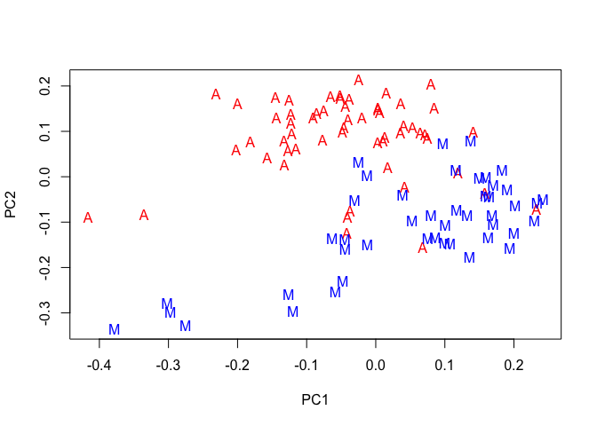

```r
plot(nyt_pca$x[,1:2],type="n")
points(nyt_pca$x[nyt_data[,"class.labels"]=="art",1:2],pch="A",col="red")
points(nyt_pca$x[nyt_data[,"class.labels"]=="music",1:2],pch="M",col="blue")
```